# Time Series Project

Suchismita Moharana

3/27/2021

### Overview and Dataset Description

The analysis here is on dataset of hourly Interstate 94 Westbound traffic volume for MN DoT ATR station 301, roughly midway between Minneapolis, MN and St Paul, MN. Hourly weather features and holidays included for impacts on traffic volume. This analysis will help in better urban planning,maintenance planning,lowering congestion level and increasing driver safety by forecasting the traffic volume for a future timeframe.

*Column Names: Datatype: Meanings*

- holiday: Categorical: US National holidays plus regional holiday, Minnesota State Fair
- temp: Numeric: Average temp in kelvin
- rain_1h: Numeric: Amount in mm of rain that occurred in the hour
- snow_1h: Numeric: Amount in mm of snow that occurred in the hour
- clouds_all: Numeric: Percentage of cloud cover
- weather_main: Categorical: Short textual description of the current weather
- weather_description: Categorical: Longer textual description of the current weather
- date_time: DateTime: Hour of the data collected in local CST time
- traffic_volume: Numeric: Hourly I-94 ATR 301 reported westbound traffic volume

```
##    holiday               temp          rain_1h            snow_1h
##  Length:48204       Min.   :  0.0   Min.   :   0.000   Min.   :0.0000000
##  Class :character   1st Qu.:272.2   1st Qu.:   0.000   1st Qu.:0.0000000
##  Mode  :character   Median :282.4   Median :   0.000   Median :0.0000000
##                     Mean   :281.2   Mean   :   0.334   Mean   :0.0002224
##                     3rd Qu.:291.8   3rd Qu.:   0.000   3rd Qu.:0.0000000
##                     Max.   :310.1   Max.   :9831.300   Max.   :0.5100000
##    clouds_all     weather_main       weather_description  date_time
##  Min.   :  0.00   Length:48204       Length:48204        Length:48204
##  1st Qu.:  1.00   Class :character   Class :character    Class :character
##  Median : 64.00   Mode  :character   Mode  :character    Mode  :character
##  Mean   : 49.36
##  3rd Qu.: 90.00
##  Max.   :100.00
##  traffic_volume
##  Min.   :   0
##  1st Qu.:1193
##  Median :3380
##  Mean   :3260
##  3rd Qu.:4933
##  Max.   :7280
```

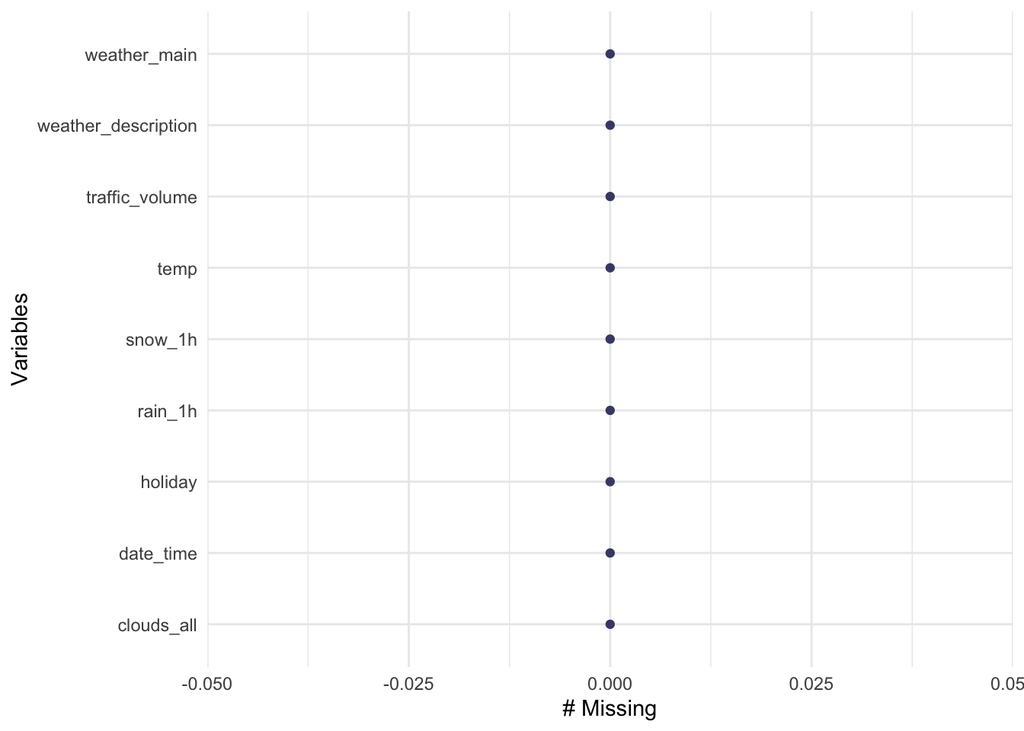

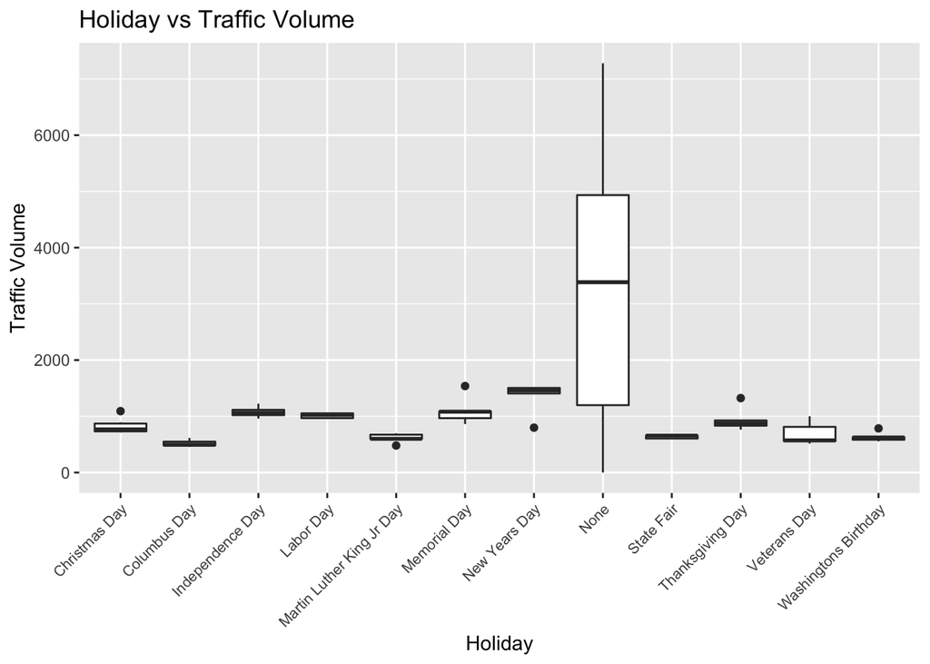

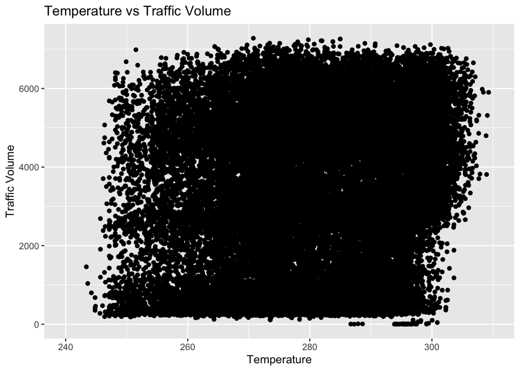

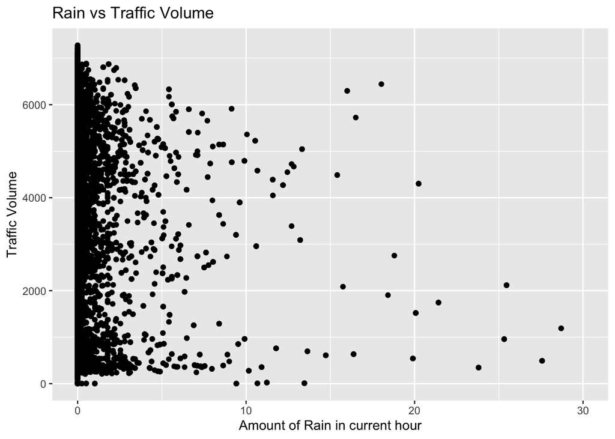

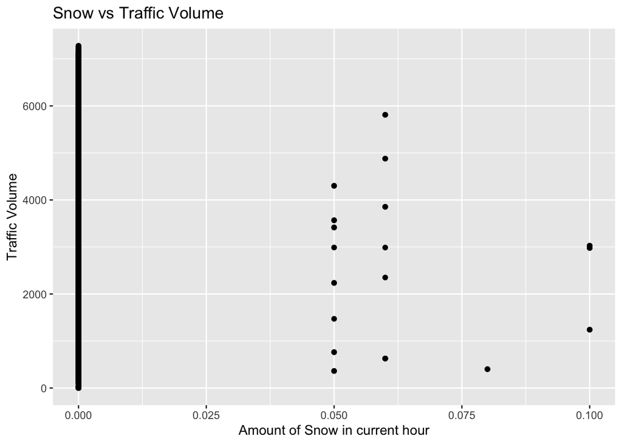

[figure not shown]

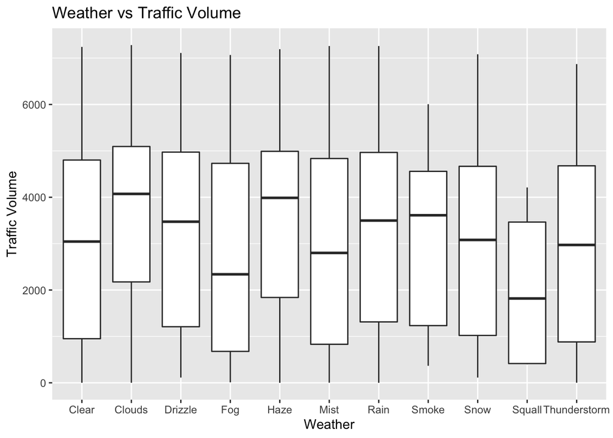

#### c. Stationary / Non-Stationary

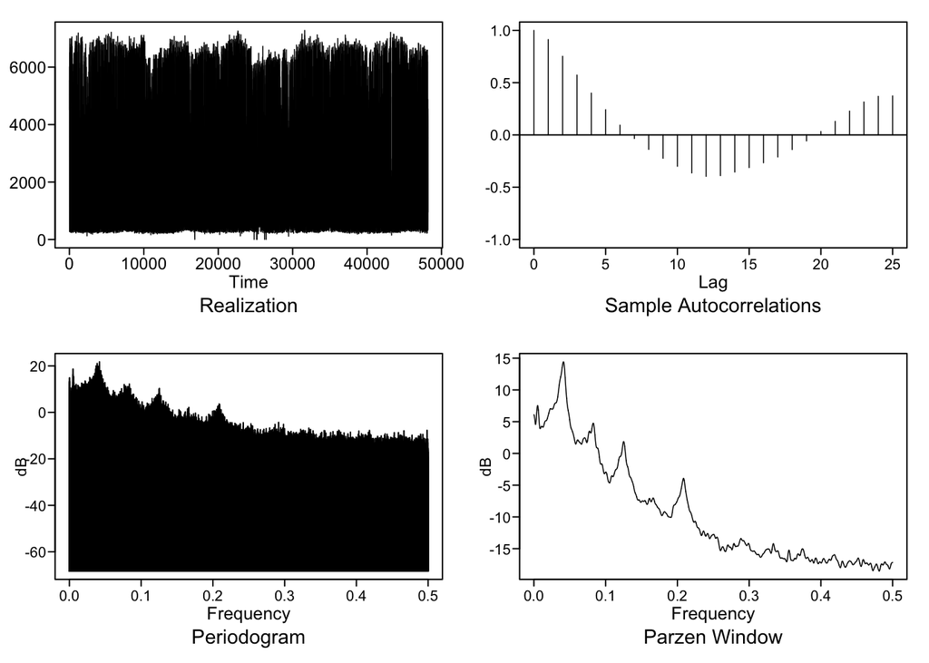

We see from the Spectral densities plot that there exist seasonal trend in the data. Hence, this model is non-stationary.

#### d. ACFs and Spectral Densities just to explore

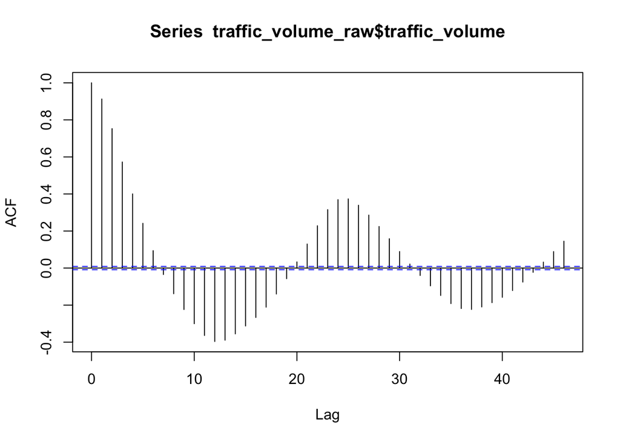

#### e. At least 2 candidate ARMA / ARIMA models

```
## ---------WORKING... PLEASE WAIT...
##
##
## Five Smallest Values of  aic
```

```
##       p    q        aic
## 17    5    1   13.10500
## 11    3    1   13.11332
## 9     2    2   13.11772
## 16    5    0   13.12522
## 13    4    0   13.13349
```

```
## ---------WORKING... PLEASE WAIT...
##
##
## Five Smallest Values of  bic
```

```
##       p    q        bic
## 17    5    1   13.10627
## 11    3    1   13.11423
## 9     2    2   13.11863
## 16    5    0   13.12631
## 13    4    0   13.13440
```

```
##
## Coefficients of Original polynomial:
## 2.0793 -1.4300 0.2632 0.1263 -0.0878
##
## Factor                 Roots                Abs Recip    System Freq
## 1-1.7949B+0.8501B^2    1.0558+-0.2485i      0.9220       0.0368
## 1-0.6363B+0.2935B^2    1.0841+-1.4940i      0.5418       0.1501
## 1+0.3520B             -2.8412               0.3520       0.5000
##
##
```

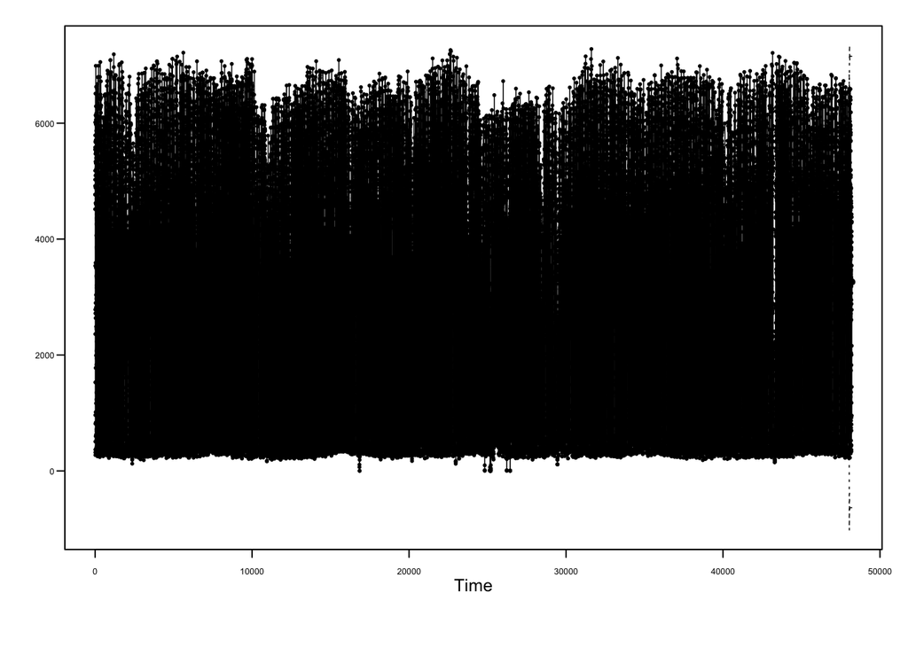

```
## [1] 3737238
```

Since we did not see much significance of Weather and Cloud Cover on Traffic volume, so I will exclude them from my multivariate analysis.

```
##
## Call:
## arima(x = traffic_volume_raw$traffic_volume, order = c(phi$p, 0, phi$q), xreg = traffic_volume_raw[,
##     2:4])
##
## Coefficients:
##          ar1      ar2     ar3      ar4      ar5      ar6     ar7      ar8
##       1.8054  -1.7865  1.0877  -0.2272  -0.0276  -0.0559  0.0377  -0.0327
## s.e.  0.0111   0.0212  0.0196   0.0140   0.0135   0.0134  0.0134   0.0129
##          ar9     ar10      ma1     ma2  intercept    temp  rain_1h    snow_1h
##       0.0614  -0.1057  -0.5125  0.7434  2369.3674  3.1647   0.1552  1802.3119
## s.e.  0.0103   0.0051   0.0102  0.0105   250.3607  0.8884   0.0416   676.2271
##
## sigma^2 estimated as 476912:  log likelihood = -383535.7,  aic = 767105.4
```

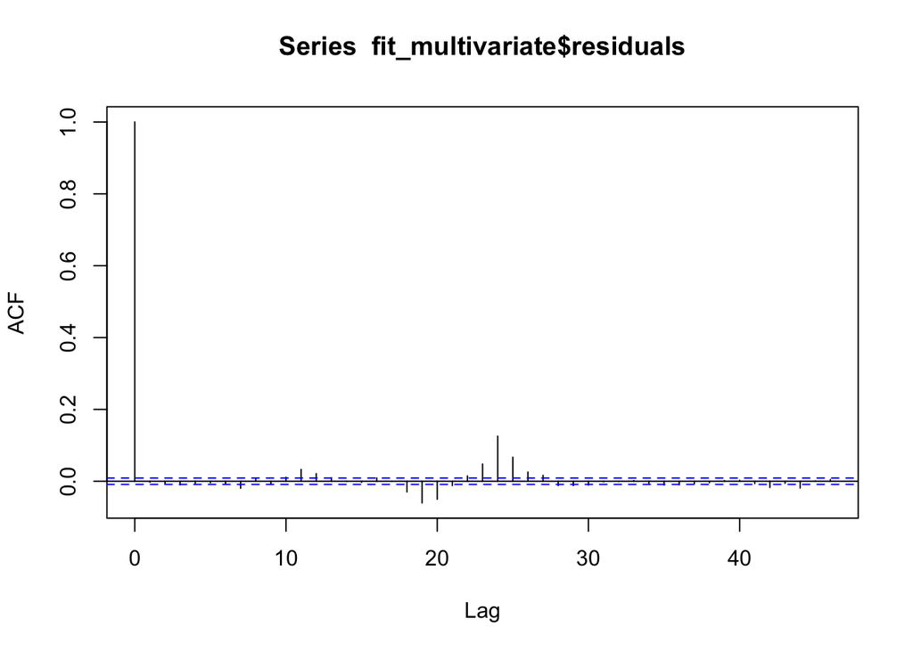

```
## Obs -0.00292617 -0.007354732 -0.009933962 -0.007310898 -0.004175401 -0.006480455 -0.01960062 0.008623157 -0.008491488 0.01096182 0.03283129 0.02112661 0.009838313 -0.000716849 -0.003150247 0.0092993 -0.0003943634 -0.0298424 -0.06047872 -0.05015213 -0.01207263 0.0146347 0.04788773 0.1255486
```

```
## [1] 0
```

```
## [1] 9617360
```